# Demo - Min Vol ETF

##### A bonus challenge in this competition is to search for new predictors not given in the [original data set](https://ucsb-erp-contest.herokuapp.com/static/ucsbdata.csv), and it is up to the participates to decide what predictors to make use of. In this demo, we will work with the [historical data of iShares Edge MSCI Min Vol USA ETF (USMV)](https://finance.yahoo.com/quote/USMV/history?p=USMV). USMV is a [minimum volatility ETF](https://www.fidelity.com/viewpoints/active-investor/minimum-volatility-ETFs) whose return presumably has certain correlation with the S&P 500 return.

### Part 1. Preparing Data

After downloading ucsbdata.csv and the USMV historical data file, which we reame to be USMV.csv, we are ready to import them into R.

```r
sp500.obj <- read.csv("ucsbdata.csv") # read ucsbdata.csv
colnames(sp500.obj)[2] <- "SP500_FORW" # rename of the variable recording the one-day-forward daily adjusted returns to "SP500"
sp500.obj$Index <- as.Date(sp500.obj$Index) # change the type of "Index" from "Factor" to "Date"
head(sp500.obj) # visulize the first few rows of sp500.obj
```

|  | Index | SP500_FORW | US10YR | EPS | PER | OPEN | HIGH | LOW | CLOSE | BDIY | VIX | PCR | MVOLE | DXY | ASP | ADVDECL | FEDFUNDS | NYSEADV | IC | BAA | NOS | BER | DVY | PTB | AAA | SI | URR | FOMC | PPIR | … |
| --- | --- | --- | --- | --- | --- | --- | --- | --- | --- | --- | --- | --- | --- | --- | --- | --- | --- | --- | --- | --- | --- | --- | --- | --- | --- | --- | --- | --- | --- | --- |
| 1 | 1952-01-02 | NA | NA | 2.44 | 9.754098 | 23.80 | 23.80 | 23.80 | 23.80 | NA | NA | NA | NA | NA | 0.2881122 | 0 | NA | NA | NA | 3.59 | NA | NA | NA | NA | 2.98 | 1.41 | 0 | 0 | 0 | … |
| 2 | 1952-01-03 | NA | NA | 2.44 | 9.786885 | 23.88 | 23.88 | 23.88 | 23.88 | NA | NA | NA | NA | NA | 0.2891479 | 0 | NA | NA | NA | 3.59 | NA | NA | NA | NA | 2.98 | 1.41 | 0 | 0 | 0 | … |
| 3 | 1952-01-04 | NA | NA | 2.44 | 9.803279 | 23.92 | 23.92 | 23.92 | 23.92 | NA | NA | NA | NA | NA | 0.2896995 | 0 | NA | NA | NA | 3.59 | NA | NA | NA | NA | 2.98 | 1.41 | 0 | 0 | 0 | … |
| 4 | 1952-01-07 | NA | NA | 2.44 | 9.799180 | 23.91 | 23.91 | 23.91 | 23.91 | NA | NA | NA | NA | NA | 0.2896456 | 0 | NA | NA | NA | 3.59 | NA | NA | NA | NA | 2.98 | 1.41 | 0 | 0 | 0 | … |
| 5 | 1952-01-08 | NA | NA | 2.44 | 9.762295 | 23.82 | 23.82 | 23.82 | 23.82 | NA | NA | NA | NA | NA | 0.2886227 | 0 | NA | NA | NA | 3.59 | NA | NA | NA | NA | 2.98 | 1.41 | 0 | 0 | 0 | … |
| 6 | 1952-01-09 | NA | NA | 2.44 | 9.729508 | 23.74 | 23.74 | 23.74 | 23.74 | NA | NA | NA | NA | NA | 0.2877206 | 0 | NA | NA | NA | 3.59 | NA | NA | NA | NA | 2.98 | 1.41 | 0 | 0 | 0 | … |

```r
usmv.obj <- read.csv("USMV.csv") # read USMV.csv
colnames(usmv.obj)[1] <- "Index" # rename of the variable recording the dates to "Index"
usmv.obj$Index <- as.Date(usmv.obj$Index) # change the type of "Index" from "Factor" to "Date"
head(usmv.obj) # visulize the first few rows of usmv.obj
```

|  | Index | Open | High | Low | Close | Adj.Close | Volume |
| --- | --- | --- | --- | --- | --- | --- | --- |
| 1 | 2011-10-20 | 25.31 | 25.36 | 25.10 | 25.36 | 21.45974 | 4200 |
| 2 | 2011-10-21 | 25.67 | 25.67 | 25.67 | 25.67 | 21.72207 | 100 |
| 3 | 2011-10-24 | 25.67 | 25.67 | 25.67 | 25.67 | 21.72207 | 0 |
| 4 | 2011-10-25 | 25.80 | 25.80 | 25.58 | 25.58 | 21.64590 | 4000 |
| 5 | 2011-10-26 | 25.73 | 25.73 | 25.46 | 25.69 | 21.73899 | 4200 |
| 6 | 2011-10-27 | 26.03 | 26.03 | 26.03 | 26.03 | 22.02670 | 100 |

As we can see, there is no variable that records the daily adjusted returns of USMV. We need to set it up ourselves. Note that
$$\text{daily adjusted returns} = \frac{\text{today's adjusted close - yesterday's adjusted close}}{\text{yesterday's adjusted close}}.$$

```r
yesterday.adj.close = c(NA, usmv.obj$Adj.Close[-nrow(usmv.obj)]) # vector that stores yesterday's adjusted close
today.adj.close = usmv.obj$Adj.Close # vector that stores today's adjusted close
usmv.obj$USMV <- (today.adj.close - yesterday.adj.close)/yesterday.adj.close # create a new variable, "USMV", in usmv.obj that records the daily adjusted returns
head(usmv.obj) # visulize the first few rows of usmv.obj
```

|  | Index | Open | High | Low | Close | Adj.Close | Volume | USMV |
| --- | --- | --- | --- | --- | --- | --- | --- | --- |
| 1 | 2011-10-20 | 25.31 | 25.36 | 25.10 | 25.36 | 21.45974 | 4200 | NA |
| 2 | 2011-10-21 | 25.67 | 25.67 | 25.67 | 25.67 | 21.72207 | 100 | 0.012224052 |
| 3 | 2011-10-24 | 25.67 | 25.67 | 25.67 | 25.67 | 21.72207 | 0 | 0.000000000 |
| 4 | 2011-10-25 | 25.80 | 25.80 | 25.58 | 25.58 | 21.64590 | 4000 | -0.003506296 |
| 5 | 2011-10-26 | 25.73 | 25.73 | 25.46 | 25.69 | 21.73899 | 4200 | 0.004300675 |
| 6 | 2011-10-27 | 26.03 | 26.03 | 26.03 | 26.03 | 22.02670 | 100 | 0.013234282 |

Let’s construct a new data frame that only stores the dates, the one-day-forward daily adjusted returns for S&P 500, and the daily adjusted returns for USMV.

```r
comb.s.tmr.u.today = merge(sp500.obj[, c("Index", "SP500_FORW")], usmv.obj[, c("Index", "USMV")], by = "Index") # tomorrow's S&P 500 and today's USMV
head(comb.s.tmr.u.today) # visulize the first few rows of comb.s.tmr.u.today
```

|  | Index | SP500_FORW | USMV |
| --- | --- | --- | --- |
| 1 | 2011-10-20 | 0.0188087120 | NA |
| 2 | 2011-10-21 | 0.0121862509 | 0.012224052 |
| 3 | 2011-10-24 | -0.0196358522 | 0.000000000 |
| 4 | 2011-10-25 | 0.0101066262 | -0.003506296 |
| 5 | 2011-10-26 | 0.0236698560 | 0.004300675 |
| 6 | 2011-10-27 | -0.0002336433 | 0.013234282 |

### Part 2. Exploring Data

Let’s now analyze the relation between the the one-day-forward daily adjusted returns for S&P 500 and the daily adjusted returns for USMV.

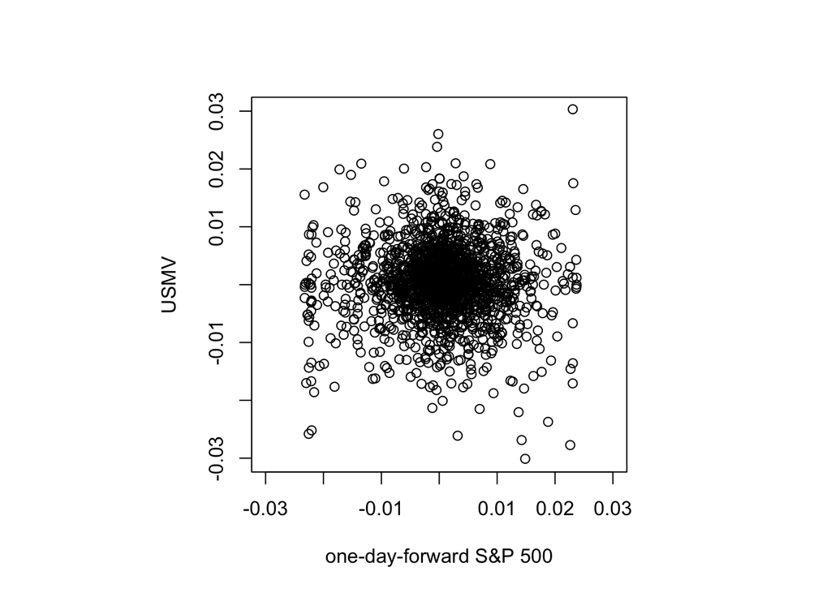

```r
par(pty="s") # square plot
plot(comb.s.tmr.u.today$SP500_FORW, comb.s.tmr.u.today$USMV, xlim=c(-0.03, 0.03), ylim=c(-0.03, 0.03), xlab = "one-day-forward S&P 500", ylab = "USMV")
```

From eyeballing, there’s no obvious relation between the two variables. In other words, we won’t be able to predict tomorrow’s S&P 500 return with only today’s USMV return, at least not in any trival way. But, you may wonder, could we use yesterday’s USMV return to predict tomorrow’s S&P 500 return? Or, instead, could we use today’s and/or yesterday’s S&P 500 return to predict tomorrow’s USMV return? There are many things we could try.

Let’s first define functions that shift every entry of a specific column in a data frame upward or downward uniformly. They will become handy.

```r
shift_upward <- function(x, n){
  c(x[(n+1):length(x)], rep(NA, n))
} # shift column x upward by n units (e.g. 1,2,3 -> 2,3,NA)
shift_downward <- function(x,n){
  c(rep(NA, n), x[1:(length(x)-n)])
} # shift column x downward by n units (e.g. 1,2,3 -> NA,1,2)
```

Let’s now analyze, say, the relation between the the one-day-backward daily adjusted returns for S&P 500 and the daily adjusted returns for USMV.

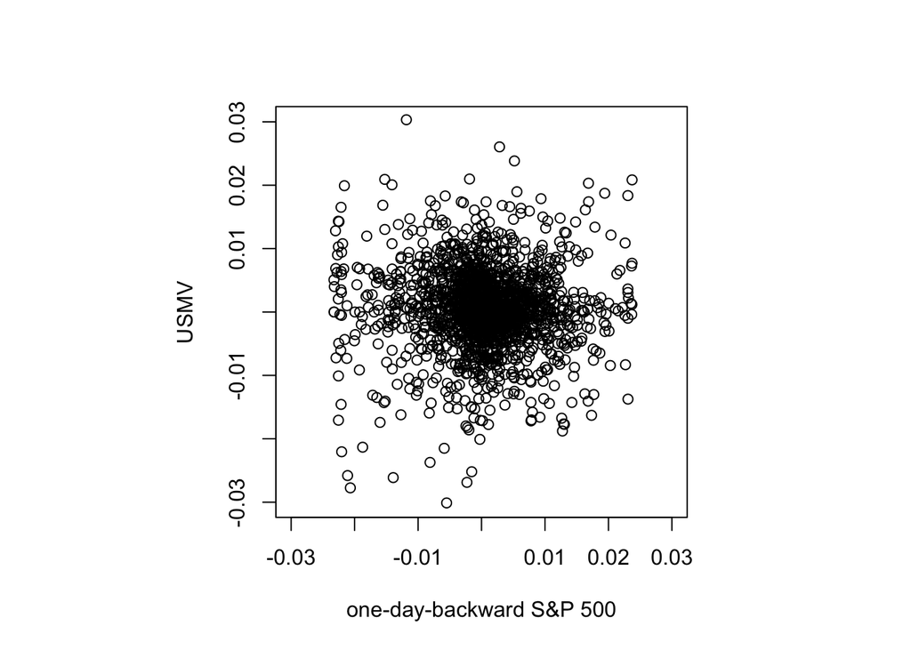

```r
comb.s.yes.u.today <- comb.s.tmr.u.today
colnames(comb.s.yes.u.today)[2] <- "SP500_BACKW"
comb.s.yes.u.today$SP500_BACKW <- shift_downward(comb.s.yes.u.today$SP500_BACKW, 2) # yesterday's S&P 500 and today's USMV
par(pty="s") # square plot
plot(comb.s.yes.u.today$SP500_BACKW, comb.s.yes.u.today$USMV, xlim=c(-0.03, 0.03), ylim=c(-0.03, 0.03), xlab = "one-day-backward S&P 500", ylab = "USMV")
```

Again, no obvious relation between the two variables. How about the relation between the the daily adjusted returns for S&P 500 and the daily adjusted returns for USMV, with no time separation?

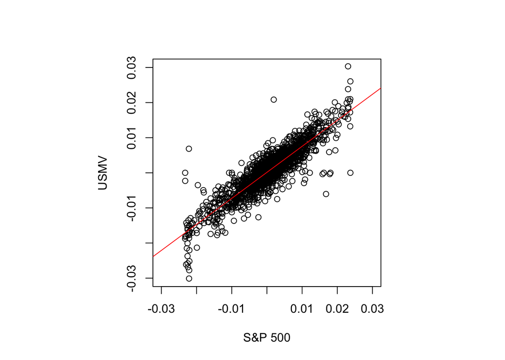

```r
comb.s.today.u.today <- comb.s.tmr.u.today
colnames(comb.s.today.u.today)[2] <- "SP500"
comb.s.today.u.today$SP500 <- shift_downward(comb.s.today.u.today$SP500, 1) # today's S&P 500 and today's USMV
par(pty="s") # square plot
plot(comb.s.today.u.today$SP500, comb.s.today.u.today$USMV, xlim=c(-0.03, 0.03), ylim=c(-0.03, 0.03), xlab = "S&P 500", ylab = "USMV")
abline(lm(comb.s.today.u.today$USMV ~ comb.s.today.u.today$SP500), col='red') # regression line
```

This makes sense: there is a strong linear relation between the the daily adjusted returns for S&P 500 and the daily adjusted returns for USMV, because the overall market behavior affects the two simultaneously. Also, the slope of the regression line here, which is clearly less than 1, shows that USMV has a smaller volatility than S&P 500, as expected. Even though this linear relation isn’t immediately useful in terms of forecasting, it’s always good to confirm it as sanity check.

Let’s now visulize the daily returns of the two as time series:

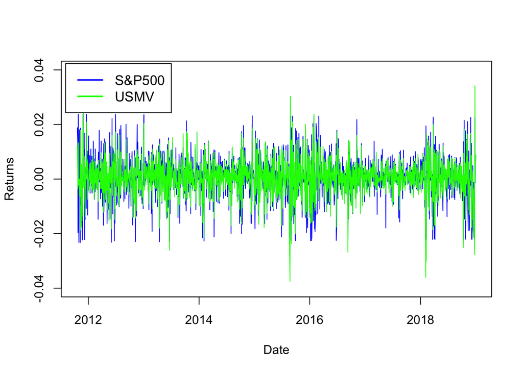

```r
plot(comb.s.today.u.today$Index, comb.s.today.u.today$SP500, type="l", lwd=1, col="blue", ylim=c(-0.04, 0.04), xlab="Date", ylab="Returns")
lines(comb.s.today.u.today$Index, comb.s.today.u.today$USMV, lwd=1, col="green")
legend("topleft", inset=0.01, legend=c("S&P500", "USMV"), col=c("blue", "green"), cex=1.1, lwd=2)
```

Taking a closer look at, say, 2018:

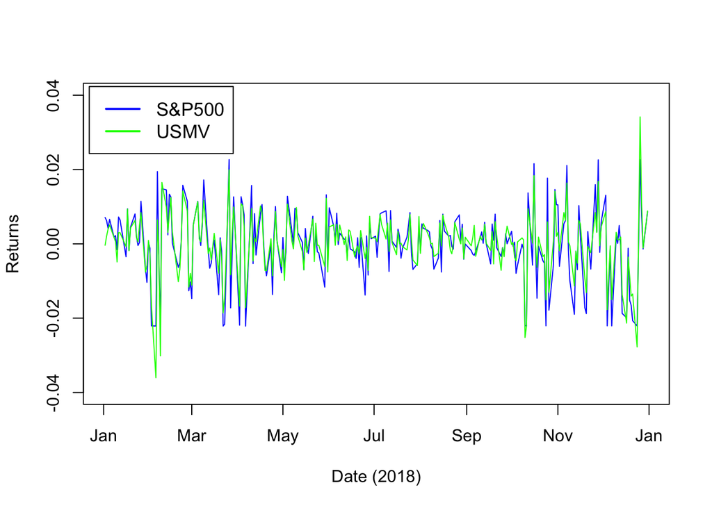

```r
time <- as.numeric(format(comb.s.today.u.today$Index, "%Y")) %in% c(2018:2018)
plot(comb.s.today.u.today[time, ]$Index, comb.s.today.u.today[time, ]$SP500, type="l", lwd=1, col="blue", ylim=c(-0.04, 0.04), xlab="Date (2018)", ylab="Returns")
lines(comb.s.today.u.today[time, ]$Index, comb.s.today.u.today[time, ]$USMV, lwd=1, col="green")
legend("topleft", inset=0.01, legend=c("S&P500", "USMV"), col=c("blue", "green"), cex=1.1, lwd=2)
```

We find that the fluctuations of the green line (USMV) are generally less than the fluctuations of the blue line （S&P 500), again confirming our expectation.

If we’d like to compare the cumulative behaviors of the two, we could use their respective daily close prices as the parameter. Assume that we start with $100 at the beginning of 2018.

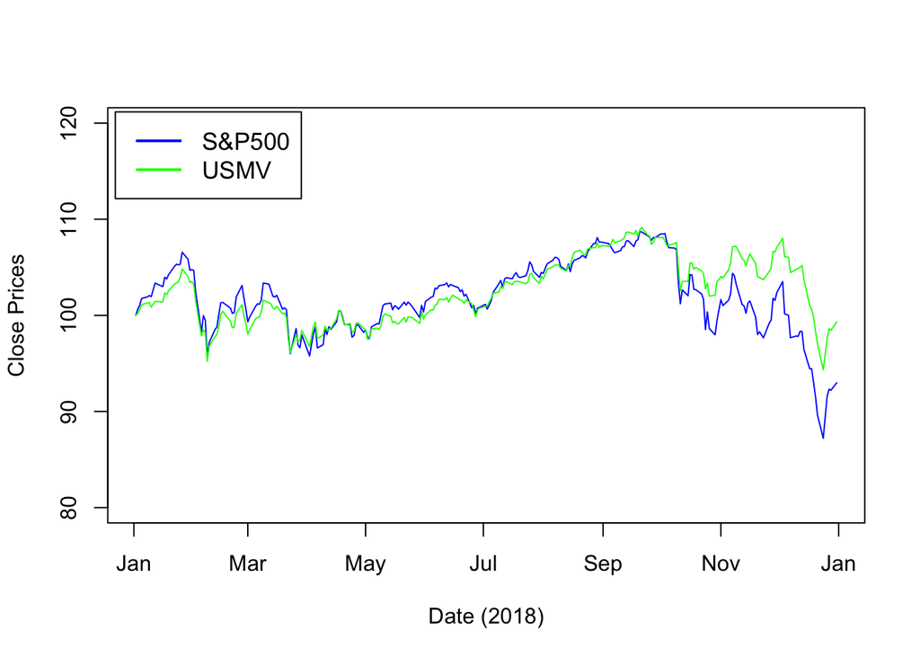

```r
comb.close = merge(sp500.obj[, c("Index", "CLOSE")], usmv.obj[, c("Index", "Close")], by = "Index")
colnames(comb.close)[2] <- "SP500_Close"
colnames(comb.close)[3] <- "USMV_Close"
plot(comb.close[time, ]$Index, comb.close[time, ]$SP500_Close/comb.close[time, ]$SP500_Close[1]*100, type="l", lwd=1, ylim=c(80, 120), col="blue", xlab="Date (2018)", ylab="Close Prices")
lines(comb.close[time, ]$Index, comb.close[time, ]$USMV_Close/comb.close[time, ]$USMV_Close[1]*100, lwd=1, col="green")
legend("topleft", inset=0.01, legend=c("S&P500", "USMV"), col=c("blue", "green"), cex=1.1, lwd=2)
```

This plot shows something really interesting. In a rising market (e.g. from April to September), USMV is supposed to underpreform the market in exchange for low volatility, but in reality it follows the market very closely. On the other hand, in a falling market (e.g. from October to December), USMV is supposed to overpreform the market, which is the case. The consequence is that, overall, USMV beats the market, a curious, recurring phenomenon called low volatility anomaly. If you want to learn more about it, feel free to contact Mark, one of the advisors for the contest.